# Le castor, ingénieur des écosystèmes – Effets sur la qualité de l’eau et les écosystèmes d’eau douce

## Message principal à retenir

Le castor crée localement des zones humides résilientes au climat

Photos et effets : Fairfax & Westbrook (2024), Fig. 2 ; texte recomposé

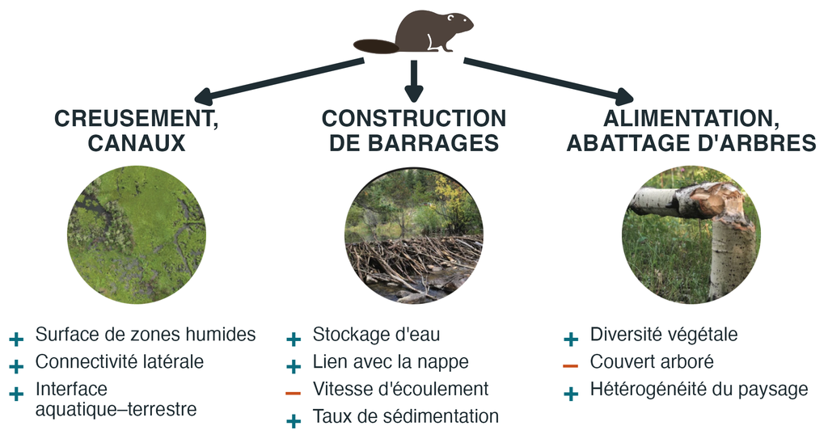

## Merci

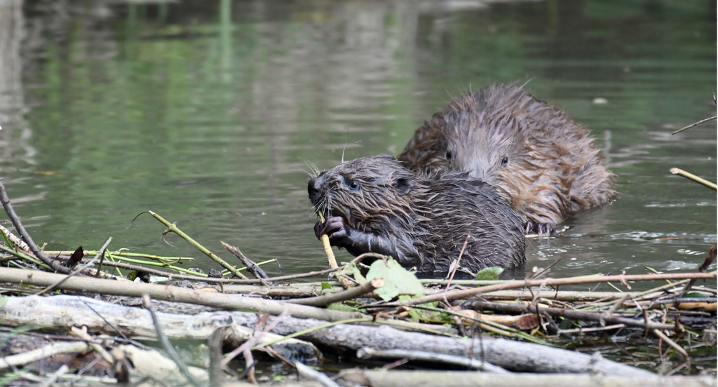

Photo : [Dominic Tinner](https://dominictinner.pro/)

**Dr. Leonardo Capitani**  
leomarameo7.github.io

[figure not shown]

## Remerciements

[figure not shown]

Dr. Leonardo Capitani is financed by the grant **“SeeWandel-Climate: Modelling the consequences of climate change and neobiota for Lake Constance”** within the framework of the Interreg VI programme **“Alpenrhein-Bodensee-Hochrhein (Germany/Austria/Switzerland/Liechtenstein)”**. The funds are provided by the European Regional Development Fund as well as the Swiss cantons.

**Les bailleurs de fonds n’ont eu aucune influence sur le contenu de cette présentation.**

[figure not shown]

## Matériel complémentaire

Diapositives supplémentaires

## Gestion du castor : une échelle de mesures

Commencer par informer ; éliminer les castors en dernier

Tab. 11.2 dans Rosell & Campbell-Palmer (2022) (modifié d’après Sjöberg & Belova 2019)

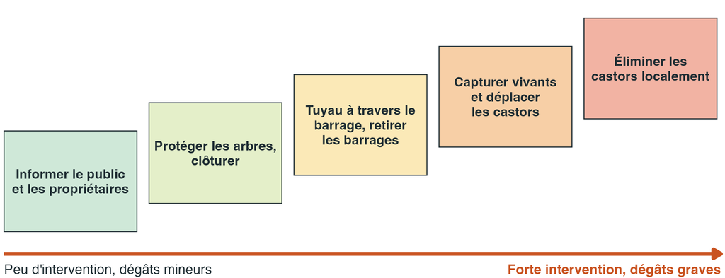

## Été et hiver : variation du COD

Les castors ajoutent du COD en été, pas en hiver

Capitani et al., en prép., Fig. 4a

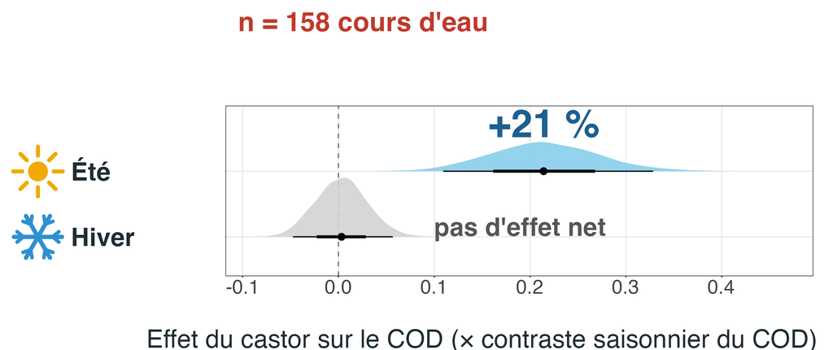

## Plan d’échantillonnage et sites

Capitani et al., en prép., Fig. 1

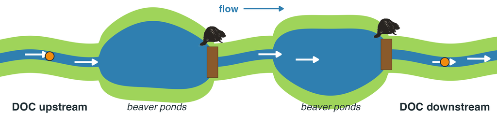

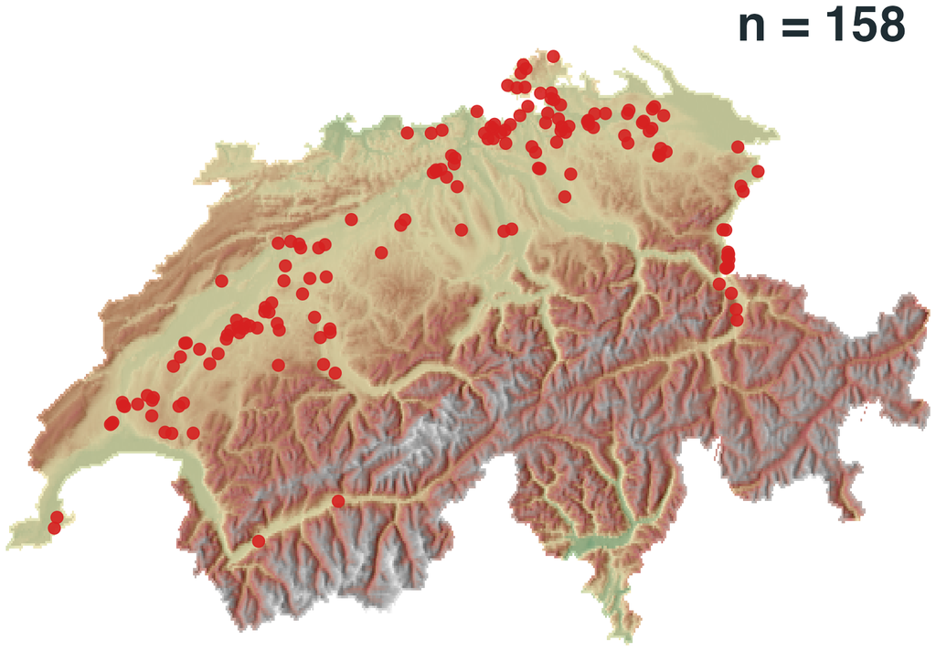

## Connectivité et expansion

Les populations isolées du nord s’étendent lentement

Fig. 3 dans [Falaschi et al. 2024, Animal Conservation 27, 324–337](https://doi.org/10.1111/acv.12910) : carte de connectivité du castor d’Eurasie en Italie et dans les pays voisins. Points sources (observations de castors) en noir, flux de courant en rouge.

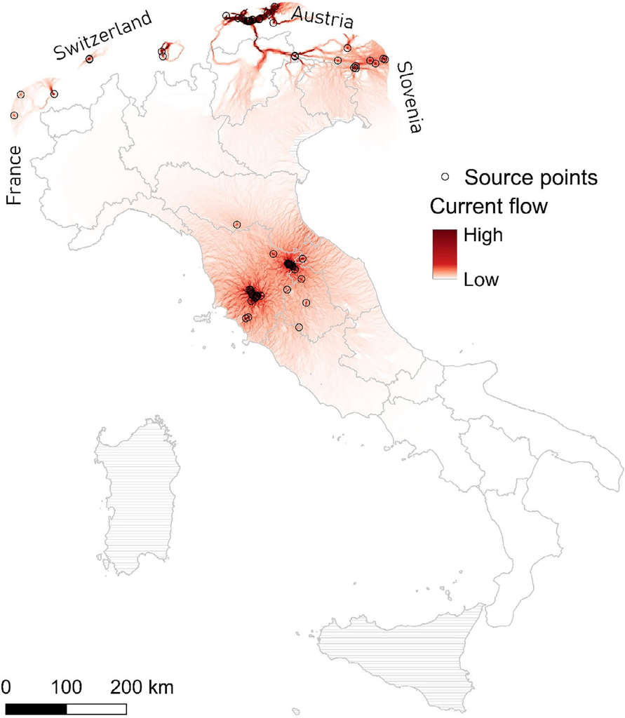

## Barrages de castors en paysage anthropisé

Les castors barrent des cours d’eau en bordure de terres agricoles

Photo : Christof Angst, in [Angst et al. 2023, Biberbestandeserhebung 2022, info fauna](https://www.infofauna.ch/de/aktuell/2023-07-06_biber-bestandeserhebung-2022#gsc.tab=0), p. 99

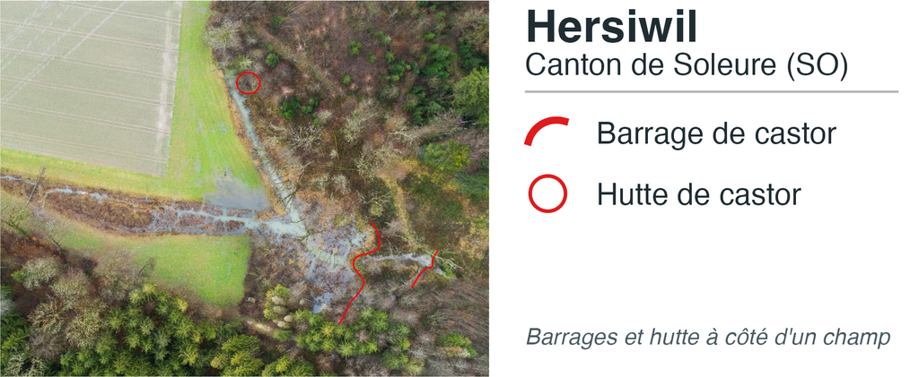

## Barrages de castors à côté de chemins et de voies ferrées

Des territoires de castors peuvent jouxter des infrastructures

Photos : Christof Angst, dans [Angst et al. 2023, Biberbestandeserhebung 2022, info fauna](https://www.infofauna.ch/de/aktuell/2023-07-06_biber-bestandeserhebung-2022#gsc.tab=0), p. 101

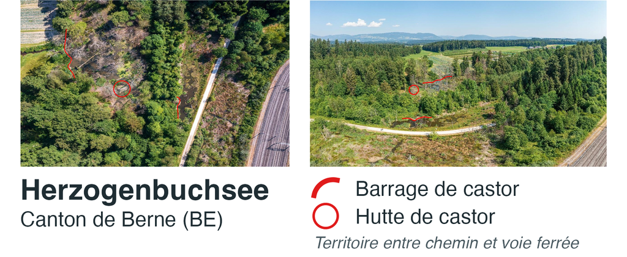

## Références (1/2)

- Angst, C., Auberson, C. & Nienhuis, C. (2023). [Biberbestandeserhebung 2022 in der Schweiz und Liechtenstein](https://www.infofauna.ch/de/aktuell/2023-07-06_biber-bestandeserhebung-2022#gsc.tab=0).
- Brazier, R.E., Puttock, A., Graham, H.A., Auster, R.E., Davies, K.H. & Brown, C.M.L. (2021). [Beaver: Nature’s ecosystem engineers](https://doi.org/10.1002/wat2.1494). *Wires. Water*, 8, e1494.
- Browning, E. (2025). [Direct and indirect impacts of beaver ecosystem engineering have mixed effects on bats across feeding guilds](https://doi.org/10.1111/1365-2656.70144). *Journal of Animal Ecology*.
- Dennis, M., Angst, C., Larsen, J.R., Rey, E. & Larsen, A. (2024). [A national scale floodplain model revealing channel gradient as a key determinant of beaver dam occurrence and inundation potential can anticipate land-use based opportunities and conflicts for river restoration](https://doi.org/10.1016/j.gecco.2024.e03304). *Global Ecology and Conservation*, 56, e03304.
- Dittbrenner, B.J., Schilling, J.W., Torgersen, C.E. & Lawler, J.J. (2022). [Relocated beaver can increase water storage and decrease stream temperature in headwater streams](https://doi.org/10.1002/ecs2.4168). *Ecosphere*, 13, e4168.
- Fairfax, E. & Westbrook, C. (2024). [The Ecology and Evolution of Beavers: Ecosystem Engineers that Ameliorate Climate Change](https://doi.org/10.1146/annurev-ecolsys-102722-122317). *Annual Review of Ecology, Evolution, and Systematics*, 55, 323‑345.
- Falaschi, M., Ficetola, G.F., Viviano, A., Mazza, G. & Mori, E. (2024). [Environmental suitability and potential range expansion of the Eurasian beaver in Italy](https://doi.org/10.1111/acv.12910). *Animal Conservation*, 27, 324‑337.
- Halley, D.J., Saveljev, A.P. & Rosell, F. (2020). [Population and distribution of beavers Castor fiber and Castor canadensis in Eurasia](https://doi.org/10.1111/mam.12216). *Mammal Review*, 51, 1‑24.

## Références (2/2)

- Jansen, J., MacIntyre, S., Barrett, D.C., Chin, Y.-P., Cortés, A., Forrest, A.L., *et al.* (2021). [Winter limnology: How do hydrodynamics and biogeochemistry shape ecosystems under ice?](https://doi.org/10.1029/2020JG006237) *Journal of Geophysical Research: Biogeosciences*, 126, e2020JG006237.
- Moser, V., Capitani, L., Zehnder, L., Hürbin, A., Obrist, M.K., Ecker, K., *et al.* (2025). [Habitat heterogeneity and food availability in beaver-engineered streams foster bat richness, activity and feeding](https://doi.org/10.1111/1365-2656.70136). *Journal of Animal Ecology*.
- Moser, V., Minnig, S., Capitani, L., Boch, S., Cramer, N., Edman, O., *et al.* (2026). [Rewilding beyond the wilderness: Beavers can restore stream biodiversity from urban to agricultural to natural landscapes](https://doi.org/10.1111/1365-2664.70439). *Journal of Applied Ecology*.
- Nationale Biberfachstelle / info fauna. (2023). [Beaver counts in the canton of Zürich, 2008–2022](https://www.infofauna.ch).
- Nyssen, J., Pontzeele, J. & Billi, P. (2011). [Effect of beaver dams on the hydrology of small mountain streams: Example from the Chevral in the Ourthe Orientale basin, Ardennes, Belgium](https://doi.org/10.1016/j.jhydrol.2011.03.001). *Journal of Hydrology*, 402, 92‑102.
- Puttock, A., Graham, H.A., Cunliffe, A.M., Elliott, M. & Brazier, R.E. (2017). [Eurasian beaver activity increases water storage, attenuates flow and mitigates diffuse pollution from intensively-managed grasslands](https://doi.org/10.1016/j.scitotenv.2016.10.122). *Science of The Total Environment*, 576, 430‑443.
- Rosell, F. & Campbell-Palmer, R. (2022). *Beavers: Ecology, Behaviour, Conservation, and Management*. Oxford University Press.
- Sheppy, J., Sudduth, E.B., Clinton, S., Riveros-Iregui, D. & Ledford, S.H. (2024). [Urban beaver ponds show limited impact on stream carbon quantity in contrast to stormwater ponds](https://doi.org/10.1007/s11252-024-01536-y). *Urban Ecosystems*, 27, 1477‑1491.